# BIOSTAT 203B: Homework #4, Exercise #4

Chad Pickering

3/16/2018

##### Connect, etc.:

```r
if (!"gridExtra" %in% rownames(installed.packages())){
  install.packages("gridExtra", repos="http://cran.rstudio.com/")
}

if (!"viridis" %in% rownames(installed.packages())){
  install.packages("viridis", repos="http://cran.rstudio.com/")
}

library(sparklyr)
library(dplyr)
library(ggplot2)
library(lubridate)
library(gridExtra)
library(viridis)

Sys.setenv(SPARK_HOME="/usr/lib/spark")
config <- spark_config()
sc <- spark_connect(master = "yarn-client", config = config)
flights_tbl <- tbl(sc, 'flights')
airports_tbl <- tbl(sc, 'airports')
airlines_tbl <- tbl(sc, 'airlines')
```

### 4. Build a predictive model for the arrival delay (`arrdelay`) of flights flying from LAX. You are allowed to use a maximum of 5 predictors.

#### Model selection:

I am subsetting the dataset to include only flights from 2003 to 2007 - predictions will be more indicative of current conditions.

##### Models attempted with >= 2003 and no other filters:

```
## Call: ml_linear_regression.tbl_spark(., arrdelay ~ depdelay + uniquecarrier + actualelapsedtime + distance)
##
## Deviance Residuals (approximate):
##       Min        1Q    Median        3Q       Max
## -62.53371  -3.84958   0.07517   3.89072 115.17152
##
## Coefficients:
##       (Intercept)          depdelay  uniquecarrier_WN  uniquecarrier_OO
##      -22.47614606        0.99810390       -1.87642288       -4.43151714
##  uniquecarrier_AA  uniquecarrier_UA  uniquecarrier_DL  uniquecarrier_AS
##       -5.76494031       -7.05808388       -4.32945958      -11.86953370
##  uniquecarrier_MQ  uniquecarrier_CO  uniquecarrier_NW  uniquecarrier_US
##       -8.29920724       -3.38734661       -5.25160670       -1.77792231
##  uniquecarrier_HP  uniquecarrier_XE  uniquecarrier_F9  uniquecarrier_TZ
##       -4.14021201       -9.90374164       -3.04777743       -4.17600398
##  uniquecarrier_FL  uniquecarrier_EV  uniquecarrier_YV  uniquecarrier_HA
##       -0.63208209       -7.20215301       -7.45676271       14.22036216
##  uniquecarrier_DH actualelapsedtime          distance
##        4.43697194        0.72809836       -0.08262772
##
## R-Squared: 0.9656
## Root Mean Squared Error: 7.301
```

#### Model performance:

Here, we generate deciles to assess model performance.

```
## $train
## # A tibble: 10 x 2
##    decile arrdelay_mean
##     <int>         <dbl>
##  1      1        137.
##  2      2         79.3
##  3      3         57.7
##  4      4         44.8
##  5      5         35.7
##  6      6         29.2
##  7      7         23.9
##  8      8         19.3
##  9      9         14.6
## 10     10          7.08
##
## $valid
## # A tibble: 10 x 2
##    decile arrdelay_mean
##     <int>         <dbl>
##  1      1        136.
##  2      2         79.7
##  3      3         57.7
##  4      4         44.6
##  5      5         35.9
##  6      6         29.3
##  7      7         23.9
##  8      8         19.2
##  9      9         14.5
## 10     10          6.93
```

The training vs. validation deciles indicate that the model is quite good.

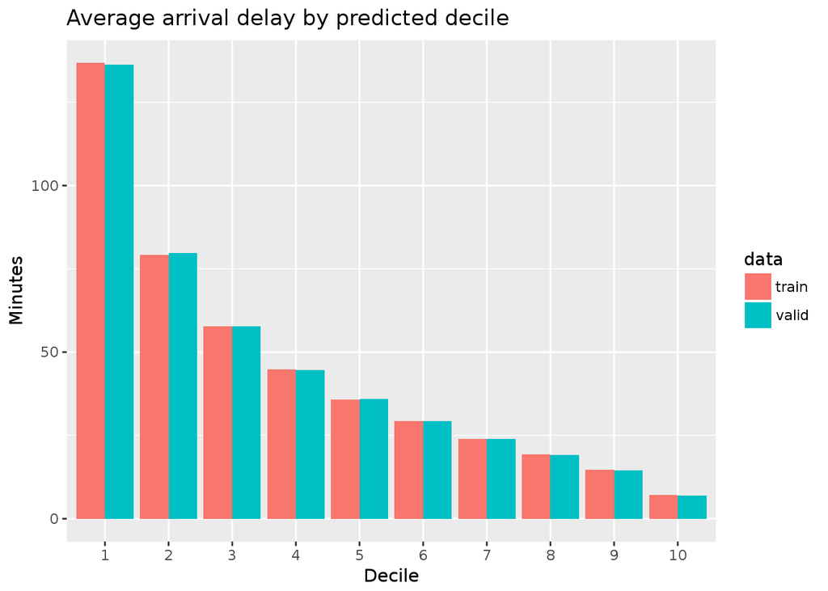

The model is biased, but still quite accurate. If predicted mean arrival delay is adjusted downwards by about two to three minutes, this would be a very well-performing model. It is still great, though.

```
## # A tibble: 13 x 4
##    description                  arrdelay_mean prediction  freq
##    <chr>                                <dbl>      <dbl> <dbl>
##  1 SkyWest Airlines Inc.                 45.3       48.8 4940.
##  2 United Air Lines Inc.                 57.3       60.5 5649.
##  3 Frontier Airlines Inc.                36.8       38.9  391.
##  4 ExpressJet Airlines Inc. (1)          51.2       51.5 1291.
##  5 Southwest Airlines Co.                42.0       44.4 9065.
##  6 Continental Air Lines Inc.            41.9       46.7 1663.
##  7 Northwest Airlines Inc.               44.7       48.3  668.
##  8 AirTran Airways Corporation           44.7       49.1  409.
##  9 US Airways Inc.                       45.5       50.2  879.
## 10 Envoy Air                             42.1       42.5 1392.
## 11 Alaska Airlines Inc.                  46.4       48.6  951.
## 12 Delta Air Lines Inc.                  39.9       46.7 1971.
## 13 American Airlines Inc.                51.3       53.7 6732.
```

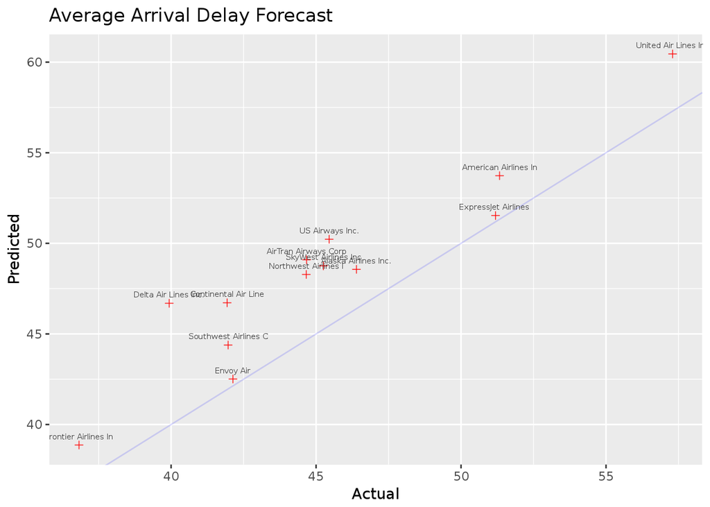